# ggplot2 & friends

```r
library(sf); library(ggplot2); library(ggpubr); library(raster); library(RColorBrewer); library(ggrepel); library(knitr)
opts_knit$set(root.dir = "~/Documents/HKU_Rusers/") # set folder directory
```

Just after our seminar I came across this blog http://r-statistics.co/Complete-Ggplot2-Tutorial-Part1-With-R-Code.html which goes through the whole ggplot(ing) process, from a simple plot to costumising and facet plotting. It’s a good starting point before diving into this document.

The aim for this document is to introduce the ggplot helper packages “ggpubr”, “ggrepel”, and “RColorBrewer”, and to show how to make your plotting code reproducable in a function.

Firstly, let’s introduce “RColorBrewer” which gives various palettes for sequential, diverging and qualitative data. One great feature is the ability to select colourblind friendly palettes.

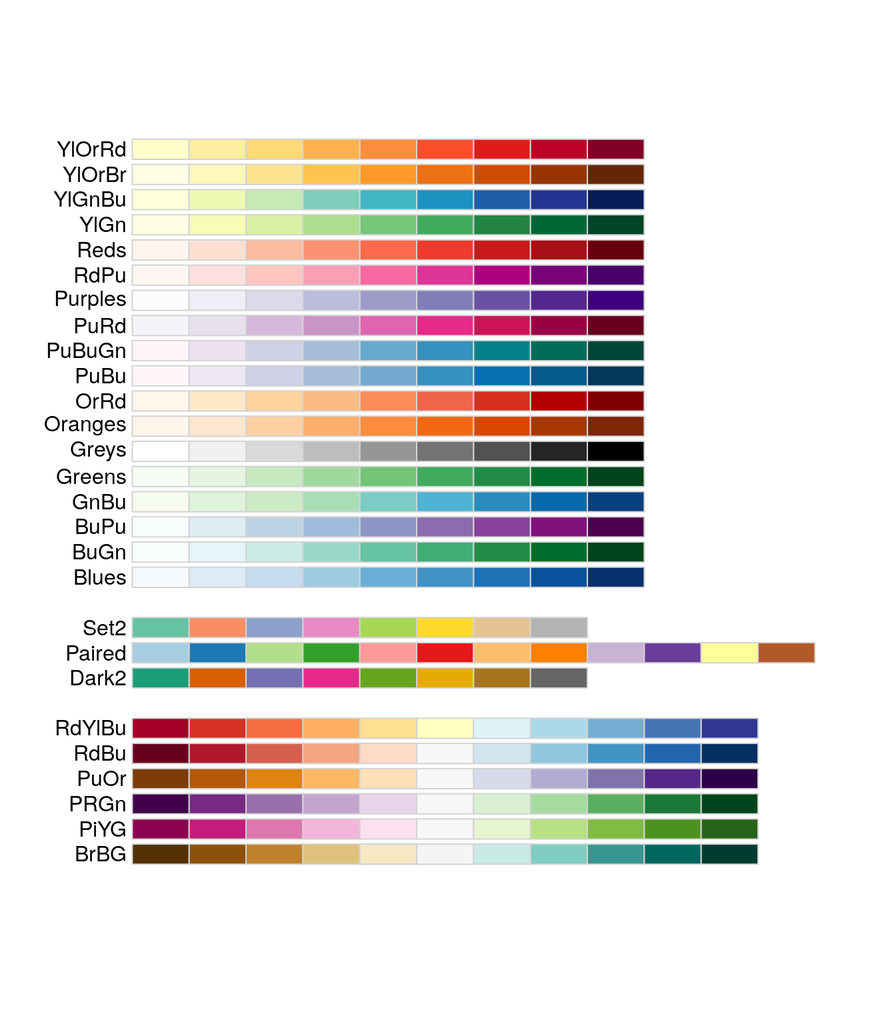

```r
RColorBrewer::display.brewer.all(colorblindFriendly = TRUE)
```

The dataset we’re using is extracted from climate models for various locations in the tropics.

```r
cmip5.reg.df <- read.csv("cmip5_reg.csv")
head(cmip5.reg.df)
```

|  | Continent | AGBGain | AGBMort | AGBnetchange | co2 | mcwd | tas |
| --- | --- | --- | --- | --- | --- | --- | --- |
| 1 | africa | 5.949030 | 4.493338 | 0.00000000 | 330.5850 | 66.93836 | 24.20209 |
| 2 | africa | 5.763319 | 4.463341 | 0.08046276 | 331.7475 | 239.74200 | 24.13701 |
| 3 | africa | 5.975065 | 4.142475 | 0.06139106 | 333.2725 | 255.95589 | 24.06863 |
| 4 | africa | 5.829013 | 4.533192 | -0.18069185 | 334.8475 | 271.00006 | 24.19125 |
| 5 | africa | 6.161512 | 4.292928 | 0.15987646 | 336.5250 | 255.51763 | 24.12875 |
| 6 | africa | 5.853155 | 4.150275 | 0.22300524 | 338.3600 | 263.43402 | 24.24149 |

Let’s plot the biomass gain and biomass loss relationship to co2, temperature and drought (mcwd). To avoid repetion this is best done as a function that takes the data.frame, the response variable (biomass gain or loss) and the explanatory variable (co2, temperature, mcwd). The function will 1) calculate the relationship between the variables using a simple linear model, 2) create a scatterplot, 3) add a trendline based on the linear model, and 4) add information about the slope.

This function also makes use of ggrepel to place text inside the plot. Placing a label in a plot can be rather difficult in ggplot as it uses the midpoint of the text label as anchor point. This creates problems, for example, in a function that outputs text labels of varying length as the text might disappear when the location is set close to x = 0. ggrepel addresses this by simply taking the start (or end) of the text label as anchor point.

You can comment parts out and repreat the plotting to see how it builds up - just remember to keep return() uncommented.

```r
PlotRegr <- function(data, response.var, expl.var) {
  # Calculate relationship using linear model
  mdl <- lm(formula = data[, response.var] ~ data[, expl.var])
  mdl <- summary(mdl) # Creates the summerary statistics for our model
  intcp <- mdl$coefficients[[1]] # to extract the value of the intercept from a named object use [[]]
  slope <- mdl$coefficients[[2]] # this extracts the slope
  pvalue <- mdl$coefficients[[8]] # this extracts the p value
  # The x-axis names and scales vary but only between three variables; it's more efficient specifying these here.
  # Note the use of list() to create callable objects
  if(expl.var=="co2"){
    x.axis <- expression(CO[2]~(ppm)) # subset 2 in CO2
    x.scale <- list(breaks = seq(330, 400, 10), limits = c(330, 400))
  }
  if(expl.var=="tas"){
    x.axis <- expression(MAT~("°C"))
    x.scale <- list(breaks = seq(18, 30, 2), limits = c(18, 30))
  }
  if(expl.var=="mcwd"){
    x.axis <- expression(MCWD~(mm))
    x.scale <- list(breaks = seq(0, 800, 200), limits = c(-5, 810))
  }
  # As with x-axis
  if (response.var=="AGBGain") y.name <- expression(Carbon~gains~(Mg~C~ha^{-1}~yr^{-1}))
  if (response.var=="AGBMort") y.name <- expression(Carbon~losses~(Mg~C~ha^{-1}~yr^{-1}))

  # The actual plotting command; note the use of aes_string() rather than aes(), aes_string() accepts out function input as character strings
  # We want to colour the continents differently to identify them in our plot so we specifiy the colour of the shape.
  p <- ggplot(data, aes_string(expl.var, response.var, colour = "Continent"))
  # Next we decide what object we want to plot - in this case points for a scatter plot. There are different shapes (google the numbers).
  # We don't want any fill i.e. just the outline of the points.
  p <- p + geom_point(shape = 21, fill = NA)
  # Next add the trendline (abline) from the linear model on top of the scatter plot
  # If our p value is greater than 0.5 plot a dashed line to indicated our result is non significant.
  if (pvalue < 0.05) {
    p <- p + geom_abline(slope = slope, intercept = intcp)
  } else {
    p <- p + geom_abline(slope = slope, intercept = intcp, linetype = "dashed")
  }
  # Now adjust the scales to zoom in on the data. Rather than scale_y_continuous(limits = ...) use coord_cardesian
  # as it won't delete any points outside your range, which would change your abline!
  y.scale <- c(0, 8)
  p <- p + coord_cartesian(ylim = y.scale, xlim = x.scale[[2]])
  # To specify the spacing then use scale_x/y_continuous
  p <- p + scale_x_continuous(breaks = x.scale[[1]]) + scale_y_continuous(breaks = seq(0, 8, 2))
  # Specify the two colours - one for each continent
  p <- p + scale_color_manual(values = c("#E69F00", "#56B4E9"))
  # apply the ggpubr theme (or any other theme)
  # base_size adjusts the overall script size
  p <- p + theme_pubr(base_size = 8)
  # specify the x and y-axis labels
  p <- p + labs(x = x.axis, y = y.name)
  # subtitle in this case consists of slope and p value information
  if (pvalue < 0.001){
    # ggplot works with data.frames so we need to create a data.frame that stores our slope and pvalue and their label location in the plot
    # since our orginal plot divides by Continents this column is also required (but doesn't matter too much which continent is chosen)
    df <- data.frame(x = x.scale[[1]][1], y = y.scale[2], slp = round(slope, 4), pval = round(pvalue, 4), Continent = 'africa')
    # geom_text_repel works just as geom_text (look it up)
    p <- p + ggrepel::geom_text_repel(aes(x = x.scale[[1]][1], y = y.scale[2]),
                             label = paste0("slope=", round(slope, 4), "  p<0.001"),
                             data = df, size = 3, colour = "black")
  } else {
    df <- data.frame(x = x.scale[[1]][1], y = y.scale[2], slp = round(slope, 4), pval = round(pvalue, 4), Continent = 'africa')
    p <- p + ggrepel::geom_text_repel(aes(x = x, y = y,
                                 label = paste0("slope=", slp, "  p=", pval)),
                                 data = df, size = 3, colour = "black")
  }

  # return the ggplot object - this is important in case you want to make adjustments to the core plot
  return(p)
}
```

The next step is to actually plot some data. First, we plot only one scatterplot for explanatory value “co2”. The script might appear small, but it works better when we later plot several plots.

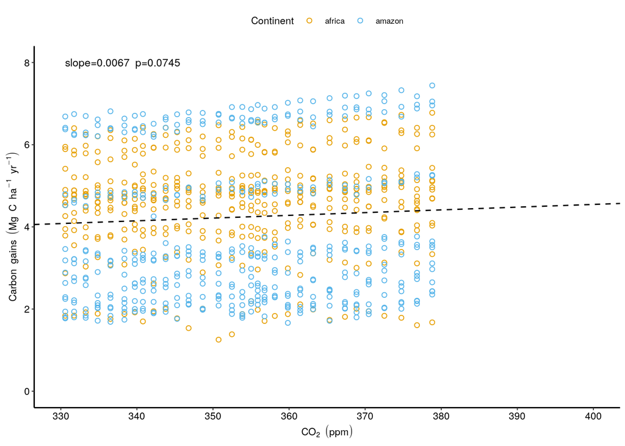

```r
PlotRegr(data = cmip5.reg.df, response.var = "AGBGain", expl.var = "co2")
```

Now we plot all explanatory variables via a for loop and store the plots as lists. That way we can access them later in ggarrange.

```r
# our x-variables
expl.vars <- c("co2", "tas", "mcwd")
# lists that will hold the plots so we can loop through them and access everthing later
gain.l <- list()
mort.l <- list()

# simple for loop to create plots
for (i in 1:length(expl.vars)){
  gain.l[[i]] <- PlotRegr(data = cmip5.reg.df, response.var = "AGBGain", expl.var = expl.vars[i])
  mort.l[[i]] <- PlotRegr(data = cmip5.reg.df, response.var = "AGBMort", expl.var = expl.vars[i])
}

# ggarrange function that combines all plots together, takes care of gridding, labelling and merging things like legends
# first all plots that need to be gridded are specified
# then number of columns and rows - be explicit and specifiy both!
# third if needed legend position and others like combined legend
p.all <- ggarrange(gain.l[[1]], gain.l[[2]], gain.l[[3]],
          mort.l[[1]], mort.l[[2]], mort.l[[3]],
          ncol = 3, nrow = 2, legend = "top", common.legend = TRUE)
```

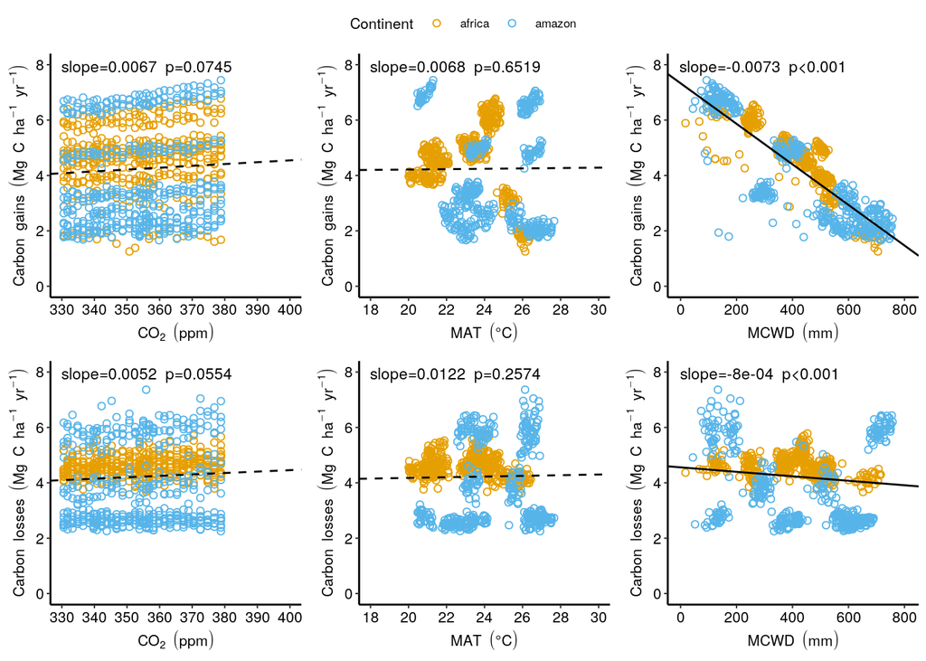

```r
p.all # silly workaround to make the plot appear without whitespace in R-Markdown
```

We can also label individual plots.

```r
# capital 'AUTO' writes capital letters, ues 'auto' for small letters
# label.x and label.y specifies label placement - 1,1 being the top left; 1,1.1 beng juuust above that; 1,0.9 would be juuust below
# font.label specifies font size, bold/italics/plain etc via specifically named items in a list
p.labels <- ggarrange(gain.l[[1]], gain.l[[2]], gain.l[[3]],
          mort.l[[1]], mort.l[[2]], mort.l[[3]],
          ncol = 3, nrow = 2, legend = "top", common.legend = TRUE,
          labels = "AUTO", label.y = 1.1, font.label = list(size = 12, face = "plain"))
```

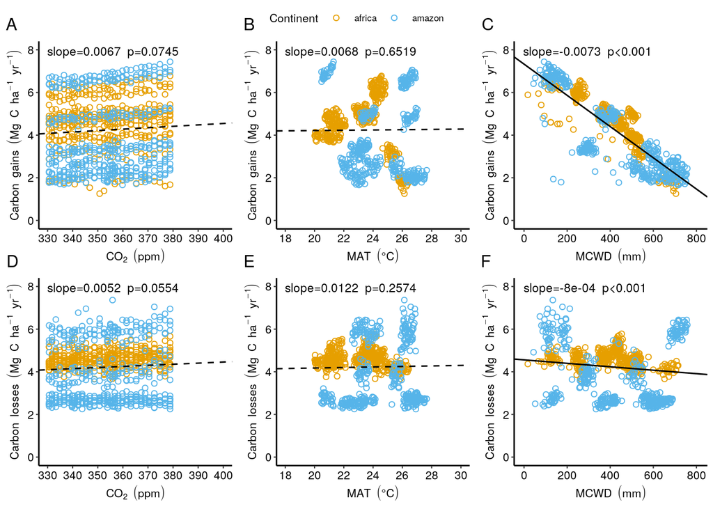

```r
p.labels
```

### Map plotting

Now let’s plot a map from raster data and some point locations. The map will focus on the tropics, but use a global country shapefile as outlines. If you don’t know what a shapefile is, Google is your friend - but in short it’s a format that stores spatial data, latitude/longitude and other information similar to a spreadsheet. In that spirit we will use the spatial features ‘sf’ package that is designed to work more efficiently with spatial data by storing spatial and associated information in a data.frame.

```r
world.shp <- "ne_110m_admin_0_countries.shp"# world & country boundary shapefile
world.shp <- read_sf(world.shp) # this reads the shapefile into R as a spatial feature sf object
obs.loc <- read.csv("sampling.csv") # sampling locations
obs.loc <- st_as_sf(obs.loc, coords = c("Lon", "Lat")) # this turns the data.frame into an sf object  - i.e. a spatial object based on lat and lon
obs.loc <- st_set_crs(obs.loc, value = "+init=epsg:4326") # the newly created sf object has no coordinate reference system associated with it, so this sets its coordinate system to the same as the world sf
cveg.r <- raster("cmip_mean_cVeg.nc") # load the raster file
```

Next we specify the plotting function. Again, we want a pretty versatile function that can handle different maps (e.g. world or country-level), colourscales, and gives output that could be expanded/amended afterwards. We can use our own coordinate system for plotting (for this purpose we keep the standard WGS84 system). Additionally the fill colour can be specified using the function calls for “scale_fill_distiller”: limits; scale; labels; type (seq, div or qual), palette (e.g. BrGn - Browns-Greens); direction (-1 indicates reverse); see more with ?scale_fill_distiller

```r
MapPlot <- function(r.file, # raster file
                    title=NULL, # optional title of plot
                    subtitle=NULL, # optional subtitle or smaller text above plot
                    legend.title=NULL, # legend title
                    region.shp, # sf object used as bounding e.g. country boundaries
                    plot.proj="+init=epsg:4326", # projection in which data will be plotted
                    size = c(100, 148), # size of the plot in mm; also takes a4 and a3 as string
                    filedir, # output directory
                    out.name=NULL, # name of the output file (if set to NULL no file is generated)
                    discrete=FALSE, # convert continuous data into discrete values
                    ...){ # additional scale and brewer pal parameters
  # prepare plotting by converting raster into points to create a dataframe with
  # latitude, longitude and raster values - this is very much the ggplot/tidyverse philosophy
  p <- raster::rasterToPoints(r.file)
  df <- data.frame(p)
  names(df) <- c("x", "y", "value")
  # if discrete scales rather than continuous are wanted, convert all values to factors
  # this assigns a discrete colour to each value
  if (discrete){
    df$value <- as.factor(df$value)
  }
  # plot using geom_tile to put together the raster, coord_equal specifies that data is plotted with a fixed aspect ratio
  p <- ggplot() + geom_tile(data = df, mapping = aes(x, y, fill=value)) + coord_equal()
  # the colorbrewer ggplot function - if left as is a white-blue scale will be used
  p <- p + scale_fill_distiller(...) # specify palette, limits, breaks
  # plots the spatial feature object on top of the raster/tile, specifies the coordinate system and that the plot should be in black and white theme
  p <- p + geom_sf(data = region.shp, alpha = 0, colour = "#666666") + coord_sf(crs = sp::CRS(plot.proj)) + theme_bw()
  # add labels
  p <- p + labs(title = title, fill = legend.title, x=NULL, y=NULL, subtitle = subtitle)
  # either save plot to figures
  if(!is.null(out.name)){
    if(size=="a4") {size <- c(210, 294)}
    if(size=="a5") {size <- c(148, 210)}
    ggsave(paste0(filedir, out.name), plot = p, device = "png", width = size[1], height = size[2], units = "mm")
  }
  # or return plot as ggplot element
  return(p)
}
```

This is what a plot would look like without any additional tweaking.

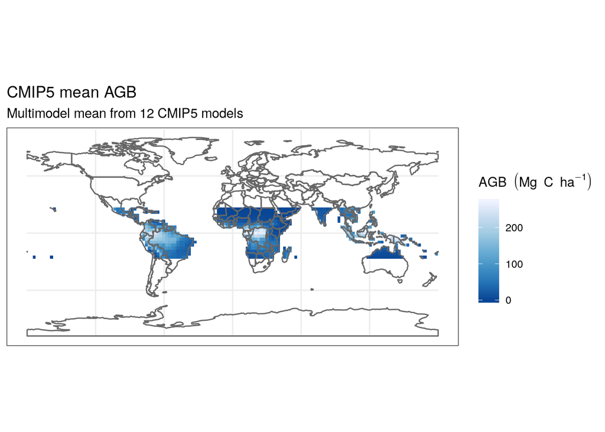

```r
MapPlot(r.file = cveg.r, region.shp = world.shp, title = "CMIP5 mean AGB", subtitle = "Multimodel mean from 12 CMIP5 models", legend.title = expression(AGB~(Mg~C~ha^{-1})))
```

We want, however, only plot the data in the tropics, and possibly with a somewhat more intuitive colour scheme (yellow is less vegetation carbon, green more).

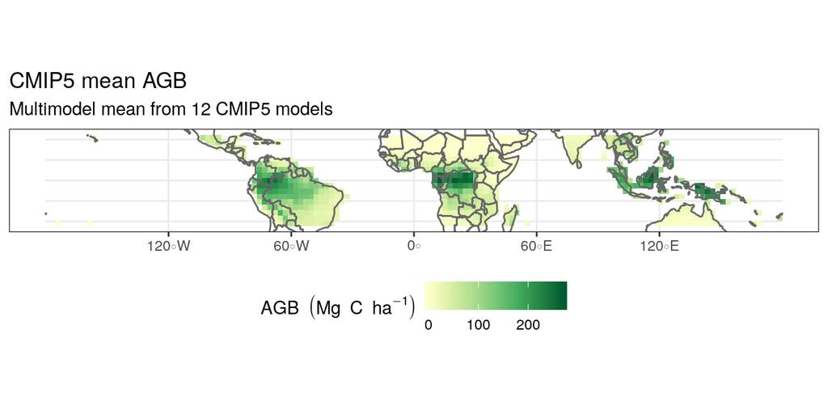

```r
mp <- MapPlot(r.file = cveg.r, region.shp = world.shp, palette = "YlGn", direction = 1, title = "CMIP5 mean AGB", subtitle = "Multimodel mean from 12 CMIP5 models",  legend.title = expression(AGB~(Mg~C~ha^{-1})))
mp <- mp + scale_y_continuous(limits = c(-23, 23)) # this clips it to the tropics
mp <- mp + theme(legend.position = "bottom")
mp
```

Now let’s add some sampling locations as red dots on top. To get the additional item to show up as a legend item it needs to be a mapped aesthetic (in aes()) and then adjusted with scale_colour_manual to remove the aesthetics title (colour) from the legend entry. Try it out without scale_colour_manual to see the effect. The parameter ‘show.legend’ makes sure the legend item is plotted as a point and not a default square. Note that even after already setting most labs, one can add to it by specifying it again.

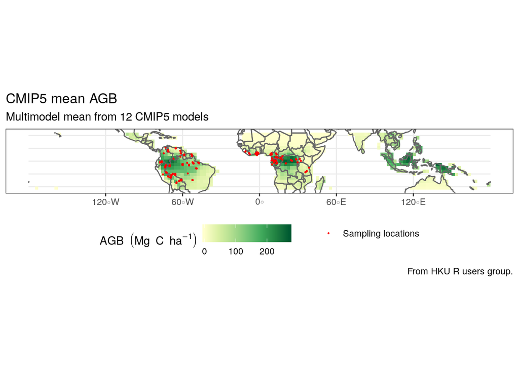

```r
mp <- mp + geom_sf(data = obs.loc, aes(colour = "Sampling locations"), size = 0.2, show.legend = "point") + scale_colour_manual(name = "", values = c("Sampling locations" = "red"))
mp <- mp + labs(caption = "From HKU R users group.")
mp
```

OK let’s combine the scatterplots and the map of the sampling locations for these plots. ggarrange has a lot of functionality - it’s best to read the ?ggarrange to learn more about it. One good example where it saves painful work in Adobe Illustrator and the like is through ‘heights’ which specifies the row-heights. In our example two rows, at a ratio of 2:1.4.

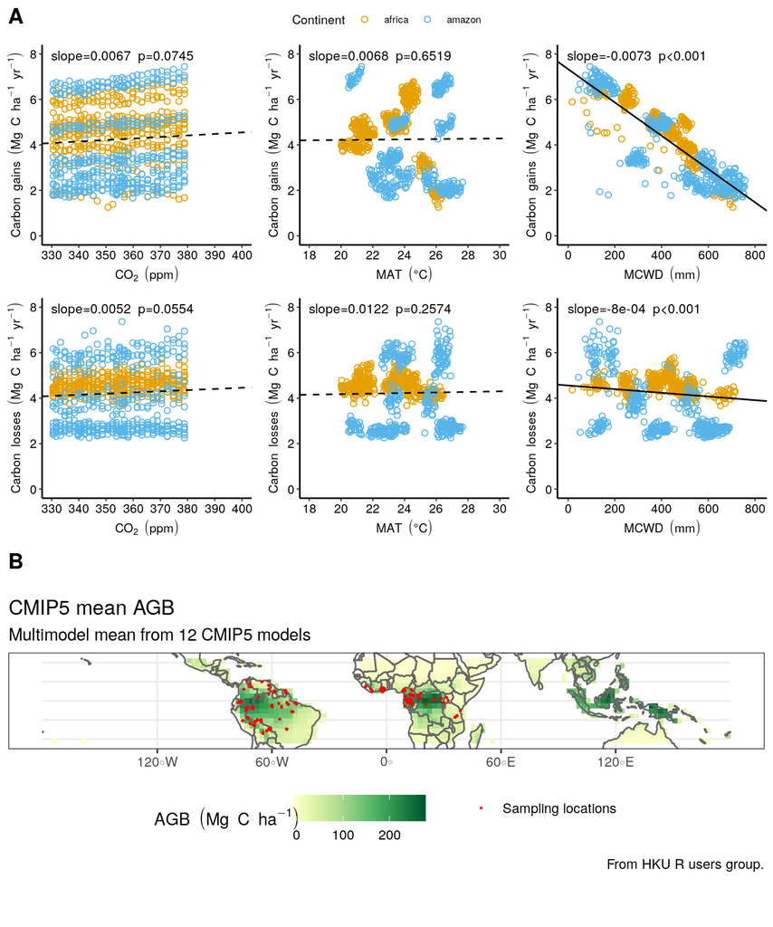

```r
ggarrange(p.all, mp, nrow = 2, labels = "AUTO", heights = c(2,1.4))
```